# Introdução ao R - Sessão 4.1

Parametrização geral de Gráficos

Tiago Ferreira

Novembro 4, 2020

AGENDA | Parametrização geral de Gráficos

**1. Desenvolvimento de gráficos no R**  
**2. Definição geral de parâmetros de objetos gráficos**  
**3. Definição de parâmetros de gráficos: Pontos e linhas**  
**4. Definição de parâmetros de gráficos: Cores**  
**5. Definição de parâmetros de gráficos: Texto**  
**6. Definição de parâmetros de gráficos: Dimensões**  
**7. Definição de parametros de gráficos: Linhas de referência**  
**8. Definição de parâmetros de gráficos: Legendas**  
**9. Definição de parâmetros de gráficos: Notas de texto**  
**10. Combinação de gráficos**

# 1. Desenvolvimento de gráficos no R

No R a criação de gráficos é feita pela adição de argumentos que vão definindo os diferentes parâmetros da representação. As funcionalidades básicas do R permitem criar e parametrizar vários tipos de gráficos. Embora existam pacotes dedicados exclusivamente à programação de gráficos, neste workshop abordamos a criação de gráficos através das funcionalidades base do R.

Começamos por apresentar um exemplo simples de gráfico no R. Para tal, é necessário primeiro importar uma nova base de dados e realizamos alguns procedimentos básicos de organização e gestão.

```r
bechdel <-
  read.csv(
    "G:\\My Drive\\FPCEUP\\R trainning\\GitRepo\\DRPMBE_R-Intro\\Tutorials\\Data\\bechdel.csv",
    header = TRUE,
    sep = ";")

bechdel$bechdel_test <- factor(bechdel$bechdel_test,
                               levels = c(1:5),
                               labels=c("no women", "no talk", "talk about men", "dubious", "pass bechdel"))
bechdel$bechdel_test_binary <-  as.factor(as.logical(bechdel$bechdel_test_binary))

names <- c("year", "movie", "bechdel_criteria", "bechdel_pass", "budget", "US_profit", "Int_profit")
names(bechdel) <- names

bechdel$year_fac <- cut(bechdel$year, pretty(bechdel$year), include.lowest=TRUE, dig.lab=4)
```

```r
names(bechdel)
```

```
## [1] "year"             "movie"            "bechdel_criteria" "bechdel_pass"
## [5] "budget"           "US_profit"        "Int_profit"       "year_fac"
```

```r
bechdel_year <- aggregate(bechdel[, c(1,5:7)], list(yeargroup = bechdel$year_fac), mean, trim=.05, na.rm=TRUE) # Here we aggregate columns 1 and 5:7 of bechdel, grouping by bechdel$year_fac, and applying the mean function.

# ?aggregate

bechdel_year
```

```
##     yeargroup     year   budget US_profit Int_profit
## 1 [1970,1980] 1976.339 42324823 231351366  328598948
## 2 (1980,1990] 1986.018 35056078 128350162  209619290
## 3 (1990,2000] 1996.942 53279498  84710431  165972945
## 4 (2000,2010] 2006.140 49611608  65517344  135484948
## 5 (2010,2020] 2011.910 56272301  67862914  164508422
```

```r
bechdel_year$year <- round(bechdel_year$year,0)
bechdel_year
```

```
##     yeargroup year   budget US_profit Int_profit
## 1 [1970,1980] 1976 42324823 231351366  328598948
## 2 (1980,1990] 1986 35056078 128350162  209619290
## 3 (1990,2000] 1997 53279498  84710431  165972945
## 4 (2000,2010] 2006 49611608  65517344  135484948
## 5 (2010,2020] 2012 56272301  67862914  164508422
```

A função plot() é uma das funções genéricas do R que permite a produção de gráficos. O seu output varia de acordo com o tipo de objetos usados como argumento.

No exemplo seguinte, os argumentos usados na função plot permitem criar um gráfico que coloca a variável **year** no eixo dos x e a variável **budget** no eixo dos y. O argumento **type=“b”** indica que os pontos do gráfico devem estar unidos por uma reta. Esse argumento pode ser alterado facilmente.

```r
plot(bechdel_year$year, bechdel_year$budget,  type="b")
```

[output not shown]

```r
# ?plot
```

# 2. Definição geral de parâmetros de objetos gráficos

Entende-se por parâmetros de gráficos todos os elementos que constituem um gráfico, nomeadamente título, eixos, símbolos e linhas utilizados, legendas, entre outros. No R todos os parâmetros dos gráficos podem ser inspecionados e modificados através da função **par()**. Sem argumentos especificados, esta função devolve os parâmetros definidos por defeito para a criação de objetos gráficos. Os argumentos definidos em par() estabelecem os parâmetros dos gráficos produzidos na sessão de trabalho. A função par() permite criar um conjunto de predefinições e estilos que podem ser guardados no R e aplicados a um determinado gráfico, sempre que desejado.

```r
#1. returns parameters
head(par())
```

```
## $xlog
## [1] FALSE
##
## $ylog
## [1] FALSE
##
## $adj
## [1] 0.5
##
## $ann
## [1] TRUE
##
## $ask
## [1] FALSE
##
## $bg
## [1] "white"
```

```r
#2. returns parameters than can be modified
head(par(no.readonly = TRUE))
```

```
## $xlog
## [1] FALSE
##
## $ylog
## [1] FALSE
##
## $adj
## [1] 0.5
##
## $ann
## [1] TRUE
##
## $ask
## [1] FALSE
##
## $bg
## [1] "white"
```

```r
# ?par
```

```r
#3. copy to opar the current graphic (default) settings that can be modified
opar <- par(no.readonly = TRUE)
head(opar)
```

```
## $xlog
## [1] FALSE
##
## $ylog
## [1] FALSE
##
## $adj
## [1] 0.5
##
## $ann
## [1] TRUE
##
## $ask
## [1] FALSE
##
## $bg
## [1] "white"
```

```r
#4. creates a plot
plot(bechdel_year$year, bechdel_year$budget,  type="b")
```

[output not shown]

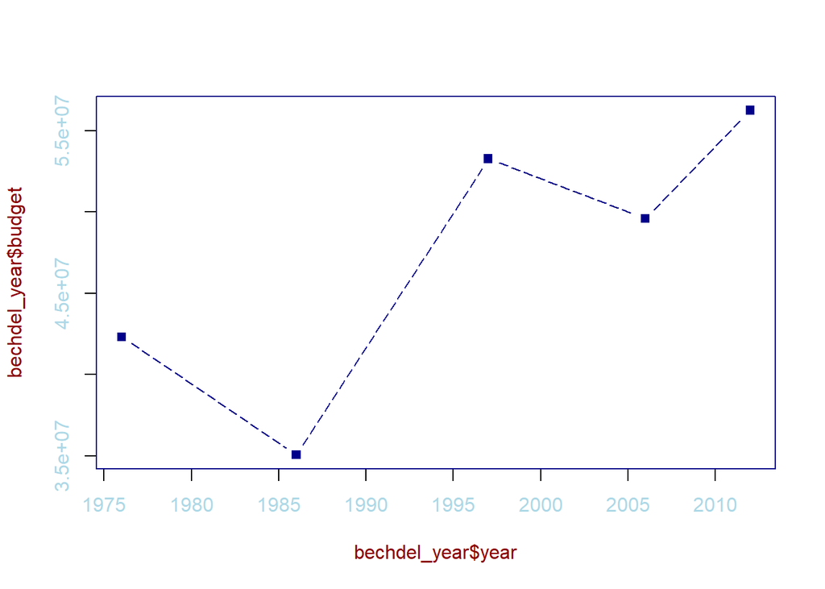

```r
#5. changes plot parameters
par(col="darkblue", col.lab="darkred", col.axis ="lightblue", lty="longdash", pch=15)

#6. creates new plot
plot(bechdel_year$year, bechdel_year$budget,  type="b")
```

```r
#7. restore the original parameters
par(opar)

#8. creates new plot with original parameters
plot(bechdel_year$year, bechdel_year$budget,  type="b")
```

[output not shown]

Uma outra forma de definir parâmetros dos gráficos é incluir os argumentos dos parâmetros na própria função que gera o gráfico. Esta abordagem especifica os parâmetros apenas para o gráfico que está a ser criado pela função de ordem superior.

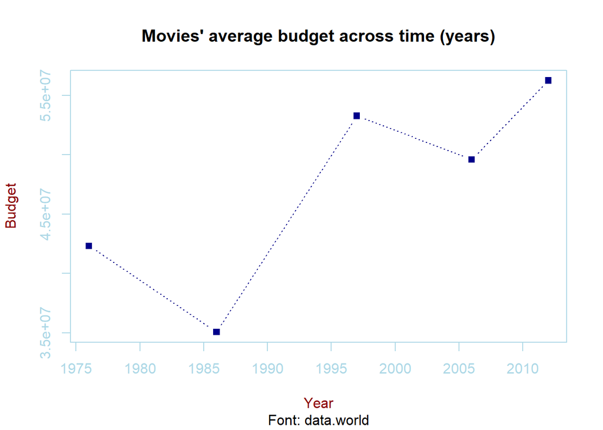

```r
#9. Creates new plot
plot(bechdel_year$year, bechdel_year$budget,  type="b",
     lty=3, pch=15,
     col="darkblue", col.lab="darkred", col.axis ="lightblue", fg="lightblue",
     main = "Movies' average budget across time (years)", sub = "Font: data.world", xlab = "Year", ylab = "Budget")
```

NOTA: Nem todos as funções que produzem gráficos permitem modificar todos os parâmetros. Verificar quais o parâmetros que podem ser modificados, chamar a ajuda para as respetivas funções (?plot, ?hist ou ?boxplot).

# 3. Definição de parâmetros de gráficos: Pontos e linhas

| Par | Desc |
| --- | --- |
| pch | Especifica tipo de ponto |
| cex | Especifica tamanho do ponto (por referência ao default = 1) |
| lty | Especifica o tipo de linha |
| lwd | Especifica grossura de linha (por referência ao default = 1) |

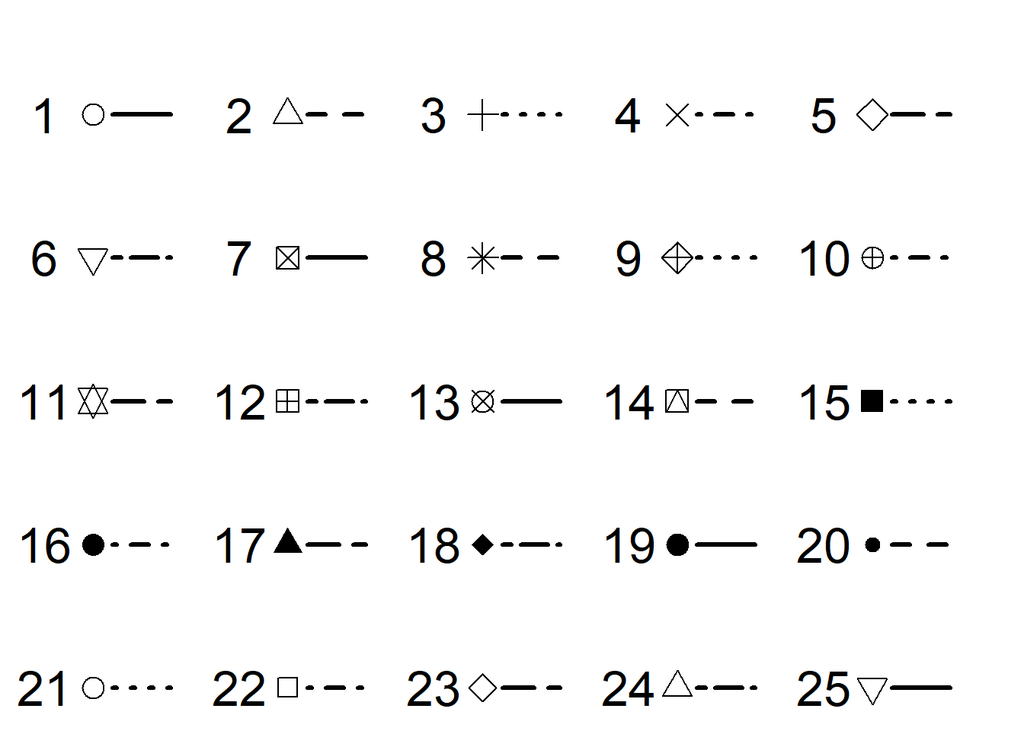

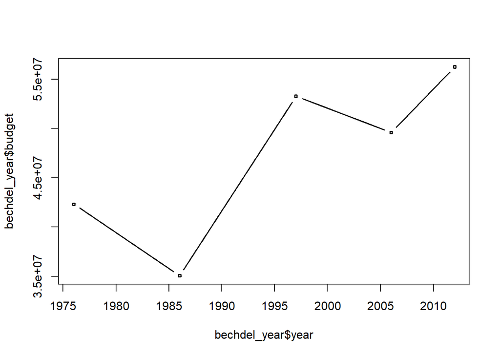

```r
plot(bechdel_year$year, bechdel_year$budget,  type="b",
     lty=19, lwd = 1.5, pch=22, cex=.5)
```

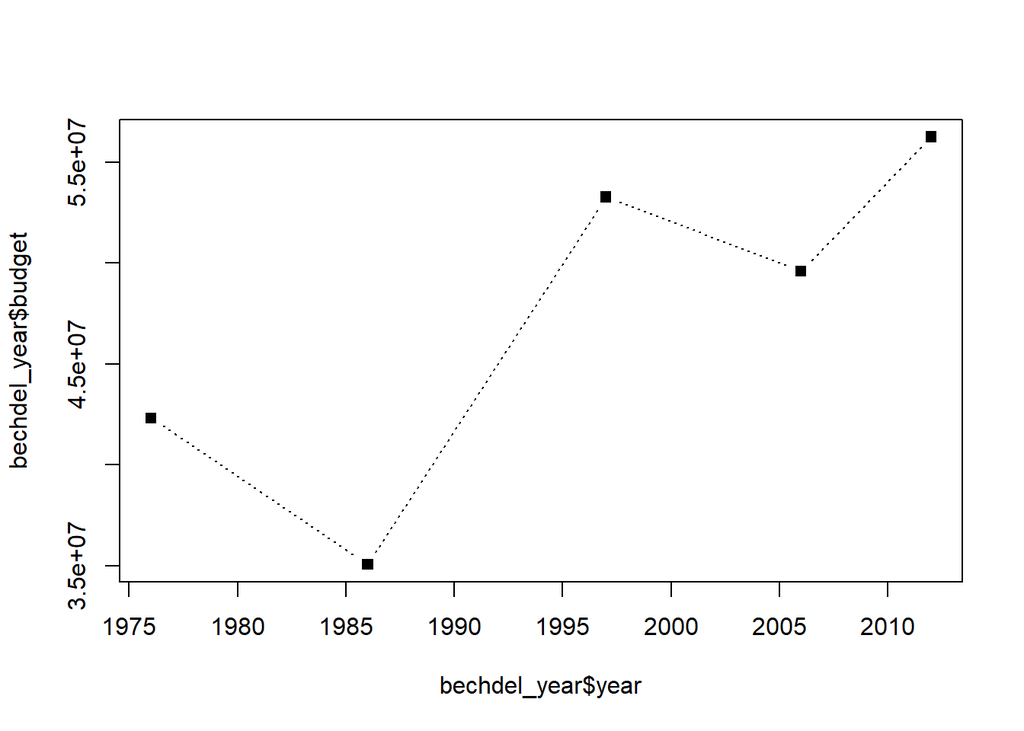

```r
plot(bechdel_year$year, bechdel_year$budget,  type="b",
     lty=3, pch=15)
```

# 4. Definição de parâmetros de gráficos: Cores

As cores podem ser definidas de várias formas no R. O utilizador poderá selecionar cores específicas ou paletes de cores definidas por pacotes. [Seguir link para informação acerta da utilização de cores no R](https://www.nceas.ucsb.edu/~frazier/RSpatialGuides/colorPaletteCheatsheet.pdf)

As cores podem ser especificadas usando o seu índice (**colors()**), nome, código hexadecimal, RGB ou HSV.

```r
#1. returns colors' names
head(colors())
```

```
## [1] "white"         "aliceblue"     "antiquewhite"  "antiquewhite1"
## [5] "antiquewhite2" "antiquewhite3"
```

```r
colors()[532]
```

```
## [1] "peachpuff2"
```

```r
#2. returs hexadecimal, RGB, and HSV codes
library(gplots)
col2hex(colors()[532])
```

```
## [1] "#EECBAD"
```

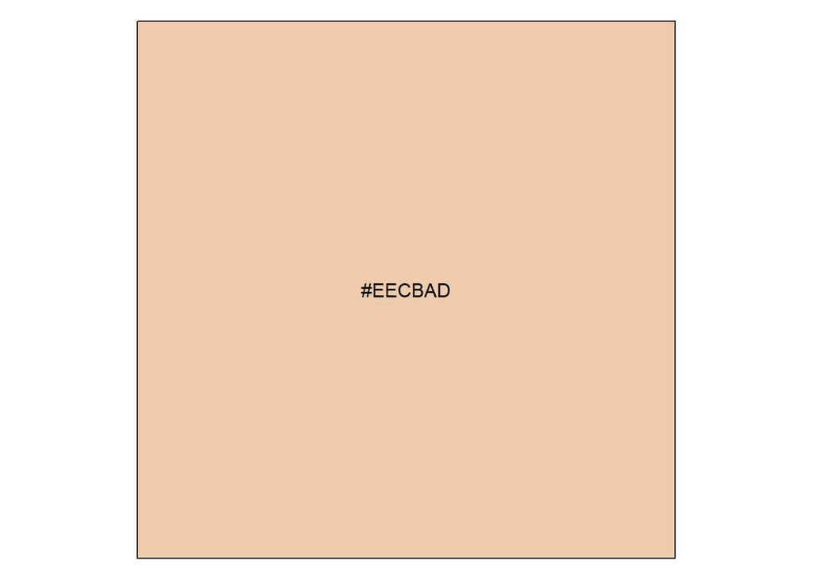

```r
# shows color given hexadecimal code
library(scales)
show_col(col2hex(colors()[532]))
```

```r
#?col2rgb
col2rgb(colors()[532])
```

```
##       [,1]
## red    238
## green  203
## blue   173
```

```r
rgb2hsv(col2rgb(colors()[532]))
```

```
##         [,1]
## h 0.07692308
## s 0.27310924
## v 0.93333333
```

```r
#3. same color dots
DF <- data.frame(x=2:6, y=rep(1, 5))
DF
```

```
##   x y
## 1 2 1
## 2 3 1
## 3 4 1
## 4 5 1
## 5 6 1
```

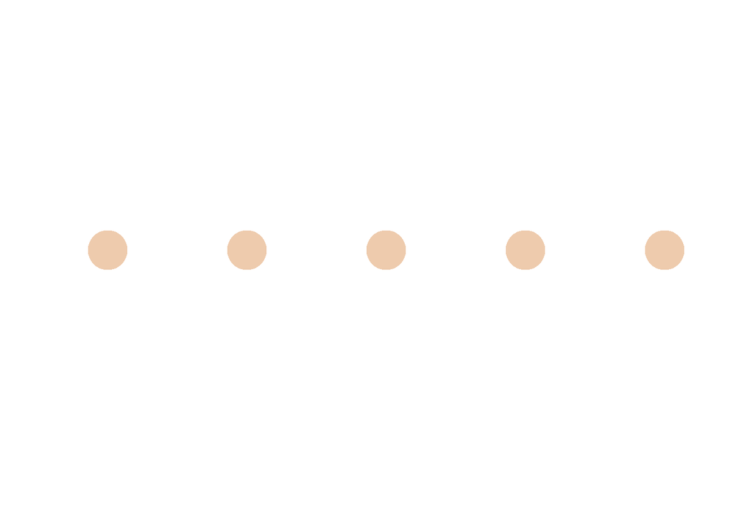

```r
plot(DF$x, DF$y, col=c(colors()[532],
                       "peachpuff2",
                       "#EECBAD",
                       rgb(238, 203, 173, maxColorValue = 255),
                       hsv(0.07692308, 0.27310924, 0.93333333)),
     pch=19, cex=5,
     axes=FALSE, ann=FALSE)
```

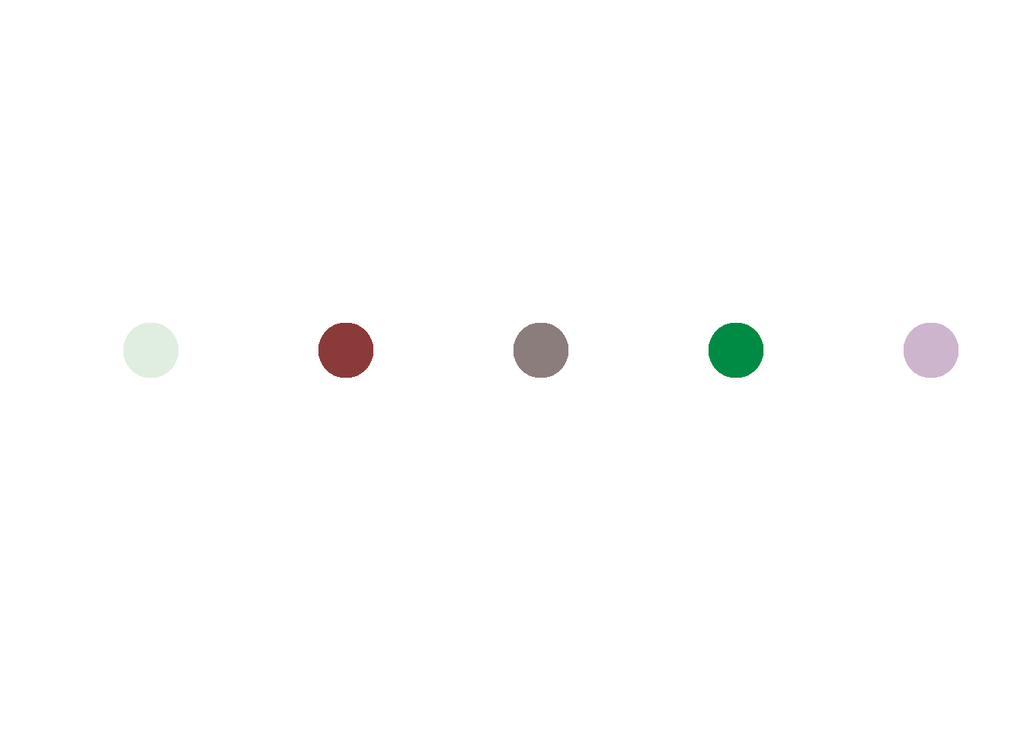

```r
#4. different color dots
plot(DF$x, DF$y, col=c("honeydew2",
                       "indianred4",
                       "mistyrose4",
                       "springgreen4",
                       "thistle3"),
     pch=19, cex=5,
     axes=FALSE, ann=FALSE)
```

Em alternativa podemos utilizar paletas de cores predefinidas por pacotes como o colorspace ou RcolorBrewer.